# Projet Statistique : Analyse des Données Médicales

15/12/2025

# 1 . Introduction

## 1.1 Contexte

Ce projet vise à étudier un jeu de données médicales contenant des informations sur les patients : âge, sexe, poids, tension artérielle, cholestérol, groupe de traitement, durée de suivi et score de symptômes.

## 1.2 Problématique

> Les caractéristiques cliniques (âge, poids, tension, cholestérol) et le traitement influencent-ils significativement l’état des patients (score de symptômes) ?

## 1.3 Objectifs

- Décrire les variables (analyse univariée)
- Étudier les relations entre variables (analyse bivariée)
- Construire un modèle explicatif (analyse multivariée)
- Tester les hypothèses statistiques

# 2 Préparation des données

## 2.1 Chargement des packages

```r
# Installer les packages si nécessaires :
# install.packages(c("tidyverse", "skimr", "GGally", "psych", "broom"))

library(tidyverse)
library(skimr)
library(GGally)
library(psych)
library(broom)
library(effsize)
```

## 2.2 Importation du jeu de données

```r
data <- read.csv(file.choose(),
                 sep = ";",
                 header = TRUE,
                 stringsAsFactors = FALSE,
                 na.strings = c("", "NA", "NaN", "NULL", "?"))

# 👀 Aperçu rapide du jeu de données
head(data)
```

```
##   ID Age Sexe Poids Tension Cholesterol Groupe_Traitement Suivi_Jours
## 1  1  63    F  48.0     130         188                 B          20
## 2  2  76    F  83.4     136         193                 B          20
## 3  3  53    M  68.4     128         200                 B          27
## 4  4  39    F  55.7     143         207                 B          21
## 5  5  67    F  63.8     150         171                 B          27
## 6  6  32    F  49.0     110          NA                 B          26
##   Symptom_Score
## 1             6
## 2             8
## 3             1
## 4            10
## 5             4
## 6             1
```

```r
str(data)
```

```
## 'data.frame':    100 obs. of  9 variables:
##  $ ID               : int  1 2 3 4 5 6 7 8 9 10 ...
##  $ Age              : int  63 76 53 39 67 32 45 63 43 47 ...
##  $ Sexe             : chr  "F" "F" "M" "F" ...
##  $ Poids            : num  48 83.4 68.4 55.7 63.8 49 64.8 81.3 65.1 57.1 ...
##  $ Tension          : num  130 136 128 143 150 110 143 136 130 106 ...
##  $ Cholesterol      : num  188 193 200 207 171 NA 181 249 NA 242 ...
##  $ Groupe_Traitement: chr  "B" "B" "B" "B" ...
##  $ Suivi_Jours      : int  20 20 27 21 27 26 29 29 21 25 ...
##  $ Symptom_Score    : int  6 8 1 10 4 1 8 1 3 4 ...
```

## 2.3 Nettoyage des données

```r
data <- data %>%
  rename(
    ID = ID,
    Age = Age,
    Sexe = Sexe,
    Poids = Poids,
    Tension = Tension,
    Cholesterol = Cholesterol,
    Groupe_Traitement = Groupe_Traitement,
    Suivi_Jours = Suivi_Jours,
    Symptom_Score = Symptom_Score
  ) %>%
  mutate(
    Sexe = as.factor(Sexe),
    Groupe_Traitement = as.factor(Groupe_Traitement)
  )

# Suppression des doublons
data <- distinct(data)

# Résumé rapide
skim(data)
```

Data summary

| Name | data |
| --- | --- |
| Number of rows | 100 |
| Number of columns | 9 |
| _______________________ |  |
| Column type frequency: |  |
| factor | 2 |
| numeric | 7 |
| ________________________ |  |
| Group variables | None |

**Variable type: factor**

| skim_variable | n_missing | complete_rate | ordered | n_unique | top_counts |
| --- | --- | --- | --- | --- | --- |
| Sexe | 0 | 1 | FALSE | 2 | M: 62, F: 38 |
| Groupe_Traitement | 0 | 1 | FALSE | 2 | A: 58, B: 42 |

**Variable type: numeric**

| skim_variable | n_missing | complete_rate | mean | sd | p0 | p25 | p50 | p75 | p100 | hist |
| --- | --- | --- | --- | --- | --- | --- | --- | --- | --- | --- |
| ID | 0 | 1.0 | 50.50 | 29.01 | 1.0 | 25.75 | 50.5 | 75.25 | 100.0 | ▇▇▇▇▇ |
| Age | 0 | 1.0 | 52.05 | 16.26 | 26.0 | 38.75 | 50.0 | 67.25 | 79.0 | ▇▇▅▇▇ |
| Poids | 10 | 0.9 | 69.38 | 15.59 | 26.8 | 59.93 | 68.9 | 80.65 | 104.1 | ▁▃▇▆▂ |
| Tension | 10 | 0.9 | 132.08 | 18.63 | 100.0 | 120.00 | 130.5 | 143.00 | 185.0 | ▅▇▇▂▁ |
| Cholesterol | 10 | 0.9 | 207.59 | 28.55 | 126.0 | 188.50 | 207.5 | 229.00 | 264.0 | ▁▃▇▇▅ |
| Suivi_Jours | 0 | 1.0 | 24.83 | 3.34 | 20.0 | 22.00 | 25.0 | 28.00 | 30.0 | ▇▃▃▃▅ |
| Symptom_Score | 0 | 1.0 | 5.78 | 2.79 | 1.0 | 3.00 | 6.0 | 8.00 | 10.0 | ▆▇▇▇▇ |

## 2.4 Gestion des valeurs manquantes

```r
colSums(is.na(data))
```

```
##                ID               Age              Sexe             Poids
##                 0                 0                 0                10
##           Tension       Cholesterol Groupe_Traitement       Suivi_Jours
##                10                10                 0                 0
##     Symptom_Score
##                 0
```

```r
data <- na.omit(data)
nrow(data)
```

```
## [1] 72
```

# 3 Analyse univariée

## 3.1 Variables quantitatives

```r
quant_vars <- c("Age", "Poids", "Tension", "Cholesterol", "Suivi_Jours", "Symptom_Score")

data %>%
  select(all_of(quant_vars)) %>%
  summary()
```

```
##       Age            Poids          Tension       Cholesterol     Suivi_Jours
##  Min.   :26.00   Min.   :26.80   Min.   :100.0   Min.   :126.0   Min.   :20
##  1st Qu.:38.00   1st Qu.:58.45   1st Qu.:118.5   1st Qu.:192.8   1st Qu.:22
##  Median :49.50   Median :69.30   Median :128.0   Median :211.0   Median :25
##  Mean   :51.97   Mean   :68.82   Mean   :130.6   Mean   :209.6   Mean   :25
##  3rd Qu.:67.25   3rd Qu.:80.35   3rd Qu.:140.0   3rd Qu.:230.2   3rd Qu.:28
##  Max.   :79.00   Max.   :99.00   Max.   :185.0   Max.   :264.0   Max.   :30
##  Symptom_Score
##  Min.   : 1.000
##  1st Qu.: 4.000
##  Median : 6.000
##  Mean   : 5.931
##  3rd Qu.: 8.000
##  Max.   :10.000
```

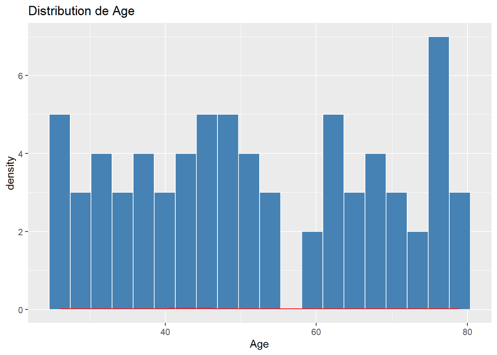

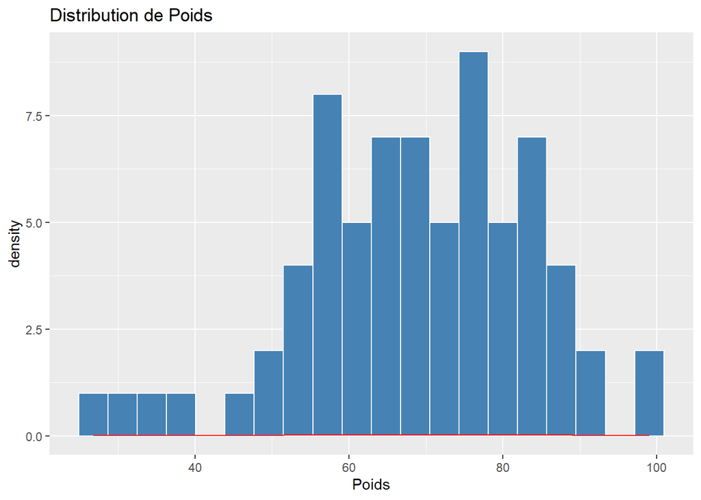

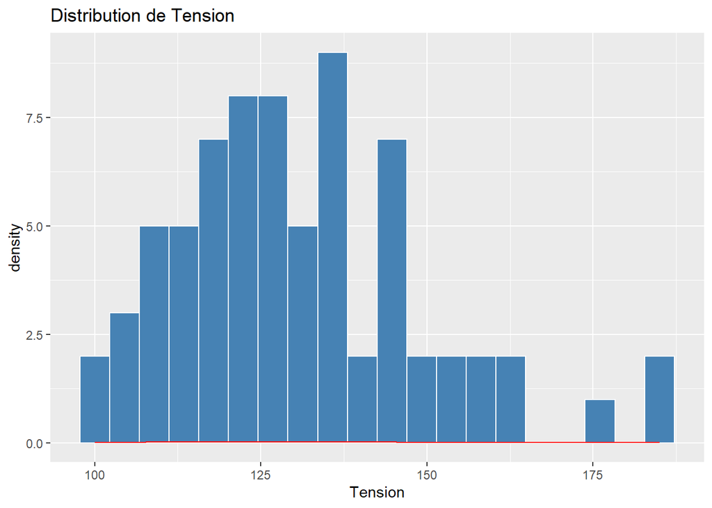

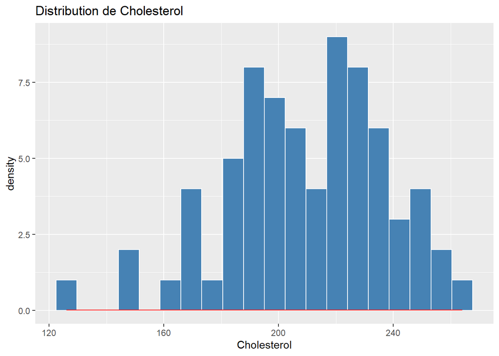

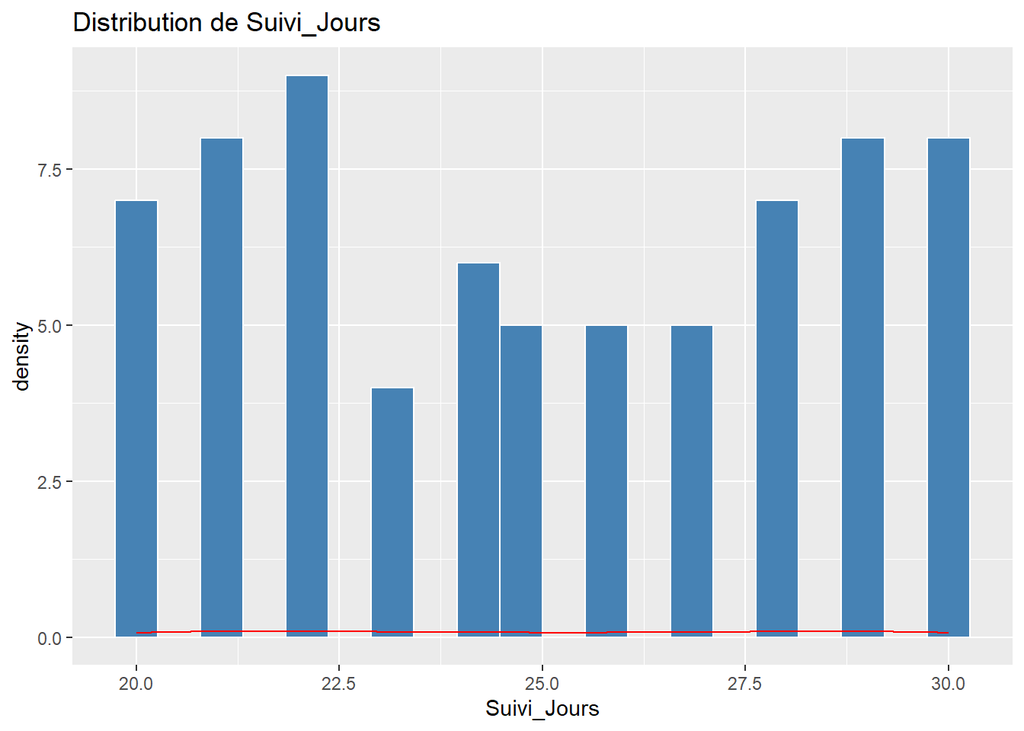

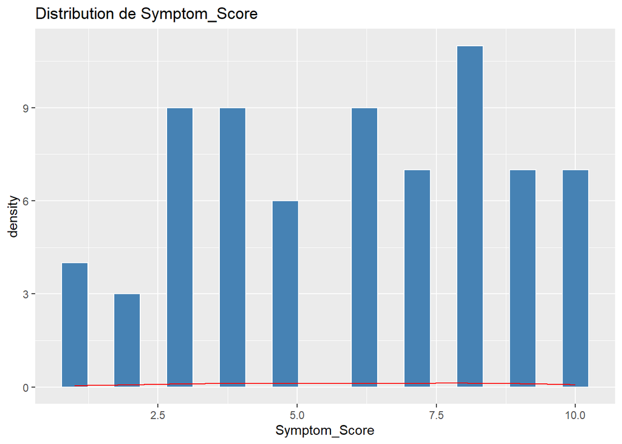

```r
# Histogrammes
for (v in quant_vars) {
  print(
    ggplot(data, aes_string(x = v)) +
      geom_histogram(bins = 20, fill = "steelblue", color = "white") +
      geom_density(alpha = 0.4, color = "red") +
      labs(title = paste("Distribution de", v))
  )
}
```

### 3.1.1 Test de normalité (Shapiro-Wilk)

```r
for (v in quant_vars) {
  cat("Variable :", v, "\n")
  x <- data[[v]]
  if (length(x) > 5000) x <- sample(x, 5000)
  print(shapiro.test(x))
  cat("\n---------------------------------\n")
}
```

```
## Variable : Age
##
##  Shapiro-Wilk normality test
##
## data:  x
## W = 0.93446, p-value = 0.001008
##
##
## ---------------------------------
## Variable : Poids
##
##  Shapiro-Wilk normality test
##
## data:  x
## W = 0.97775, p-value = 0.2312
##
##
## ---------------------------------
## Variable : Tension
##
##  Shapiro-Wilk normality test
##
## data:  x
## W = 0.95439, p-value = 0.01077
##
##
## ---------------------------------
## Variable : Cholesterol
##
##  Shapiro-Wilk normality test
##
## data:  x
## W = 0.9828, p-value = 0.4311
##
##
## ---------------------------------
## Variable : Suivi_Jours
##
##  Shapiro-Wilk normality test
##
## data:  x
## W = 0.91295, p-value = 0.0001052
##
##
## ---------------------------------
## Variable : Symptom_Score
##
##  Shapiro-Wilk normality test
##
## data:  x
## W = 0.94725, p-value = 0.00446
##
##
## ---------------------------------
```

## 3.2 Variables qualitatives

```r
table(data$Sexe)
```

```
##
##  F  M
## 30 42
```

```r
table(data$Groupe_Traitement)
```

```
##
##  A  B
## 40 32
```

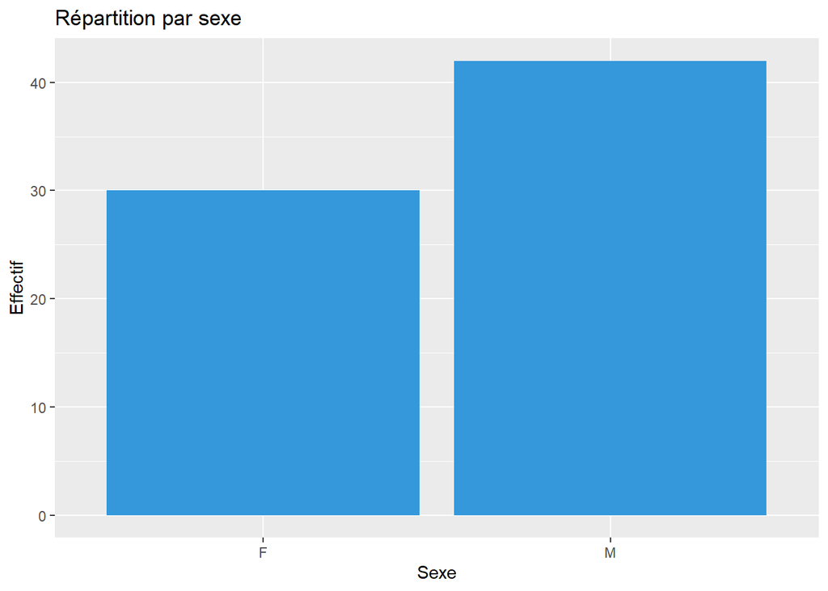

```r
ggplot(data, aes(x = Sexe)) +
  geom_bar(fill = "#3498db") +
  labs(title = "Répartition par sexe", x = "Sexe", y = "Effectif")
```

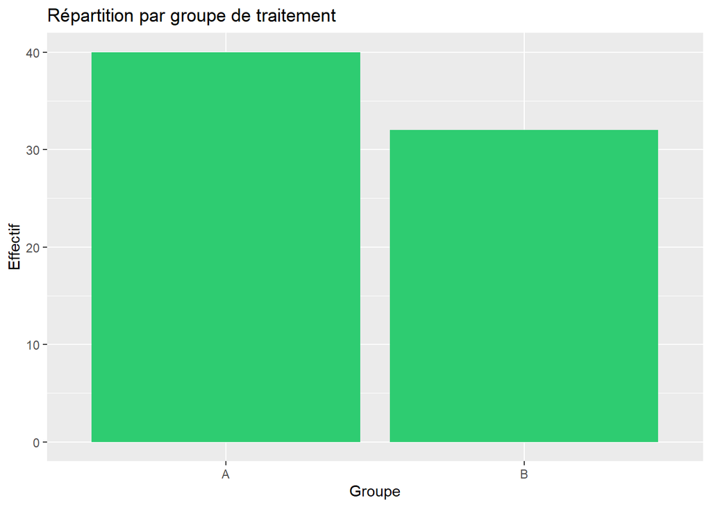

```r
ggplot(data, aes(x = Groupe_Traitement)) +
  geom_bar(fill = "#2ecc71") +
  labs(title = "Répartition par groupe de traitement", x = "Groupe", y = "Effectif")
```

# 4 Analyse bivariée

## 4.1 Corrélations entre variables quantitatives

```r
cor_matrix <- cor(data[, quant_vars])
cor_matrix
```

```
##                        Age       Poids      Tension Cholesterol Suivi_Jours
## Age            1.000000000  0.07581081 -0.007322607 -0.06885022 -0.06815034
## Poids          0.075810814  1.00000000 -0.110141073  0.06623760  0.05151972
## Tension       -0.007322607 -0.11014107  1.000000000  0.03471370 -0.03240724
## Cholesterol   -0.068850218  0.06623760  0.034713702  1.00000000  0.02892325
## Suivi_Jours   -0.068150342  0.05151972 -0.032407243  0.02892325  1.00000000
## Symptom_Score  0.168343356  0.09557221 -0.119349464 -0.03796789 -0.11738130
##               Symptom_Score
## Age              0.16834336
## Poids            0.09557221
## Tension         -0.11934946
## Cholesterol     -0.03796789
## Suivi_Jours     -0.11738130
## Symptom_Score    1.00000000
```

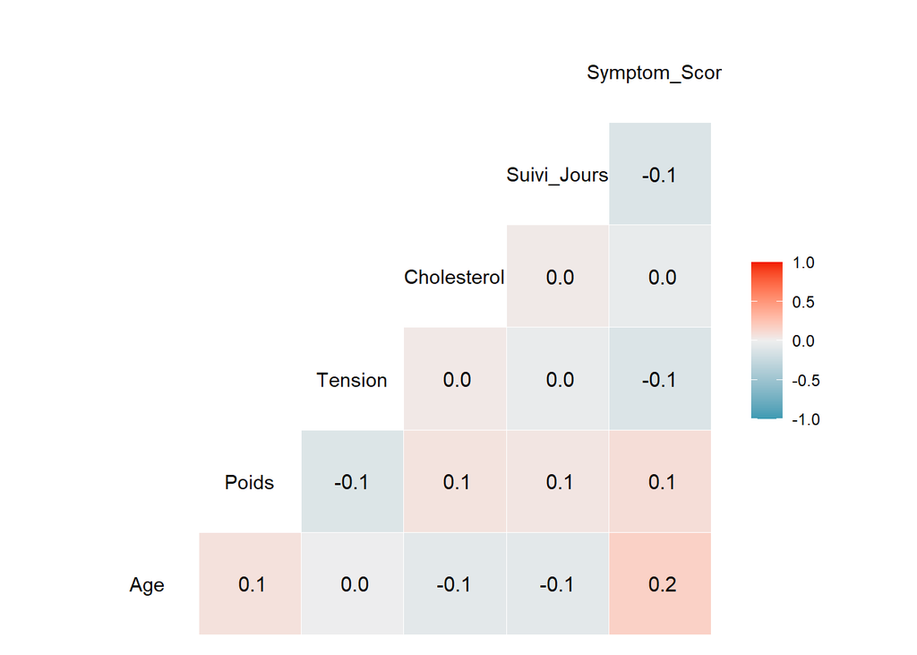

```r
GGally::ggcorr(data[, quant_vars], label = TRUE)
```

### 4.1.1 Exemple : Corrélation entre âge et score de symptômes

```r
cor.test(data$Age, data$Symptom_Score)
```

```
##
##  Pearson's product-moment correlation
##
## data:  data$Age and data$Symptom_Score
## t = 1.4289, df = 70, p-value = 0.1575
## alternative hypothesis: true correlation is not equal to 0
## 95 percent confidence interval:
##  -0.0658951  0.3849971
## sample estimates:
##       cor
## 0.1683434
```

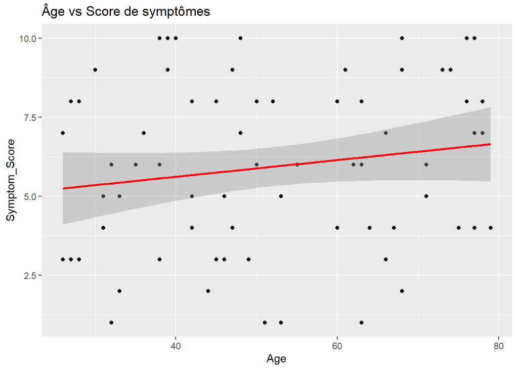

```r
ggplot(data, aes(x = Age, y = Symptom_Score)) +
  geom_point() +
  geom_smooth(method = "lm", color = "red") +
  labs(title = "Âge vs Score de symptômes")
```

## 4.2 Comparaison de moyennes (score selon le traitement)

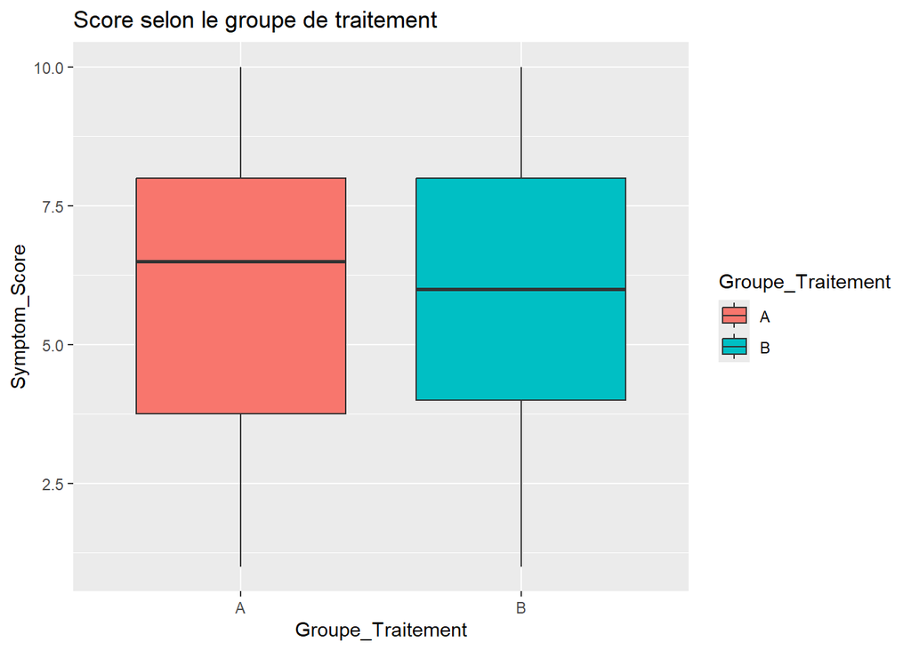

```r
ggplot(data, aes(x = Groupe_Traitement, y = Symptom_Score, fill = Groupe_Traitement)) +
  geom_boxplot() +
  labs(title = "Score selon le groupe de traitement")
```

```r
# Test ANOVA
anova_test <- aov(Symptom_Score ~ Groupe_Traitement, data = data)
summary(anova_test)
```

```
##                   Df Sum Sq Mean Sq F value Pr(>F)
## Groupe_Traitement  1    2.6   2.584   0.366  0.547
## Residuals         70  494.1   7.058
```

```r
# Test non paramétrique
kruskal.test(Symptom_Score ~ Groupe_Traitement, data = data)
```

```
##
##  Kruskal-Wallis rank sum test
##
## data:  Symptom_Score by Groupe_Traitement
## Kruskal-Wallis chi-squared = 0.28129, df = 1, p-value = 0.5959
```

## 4.3 Variables qualitatives (Sexe vs Groupe de traitement)

```r
tab <- table(data$Sexe, data$Groupe_Traitement)
tab
```

```
##
##      A  B
##   F 14 16
##   M 26 16
```

```r
chisq.test(tab)
```

```
##
##  Pearson's Chi-squared test with Yates' continuity correction
##
## data:  tab
## X-squared = 1.0864, df = 1, p-value = 0.2973
```

### 4.3.1 Visualisation :

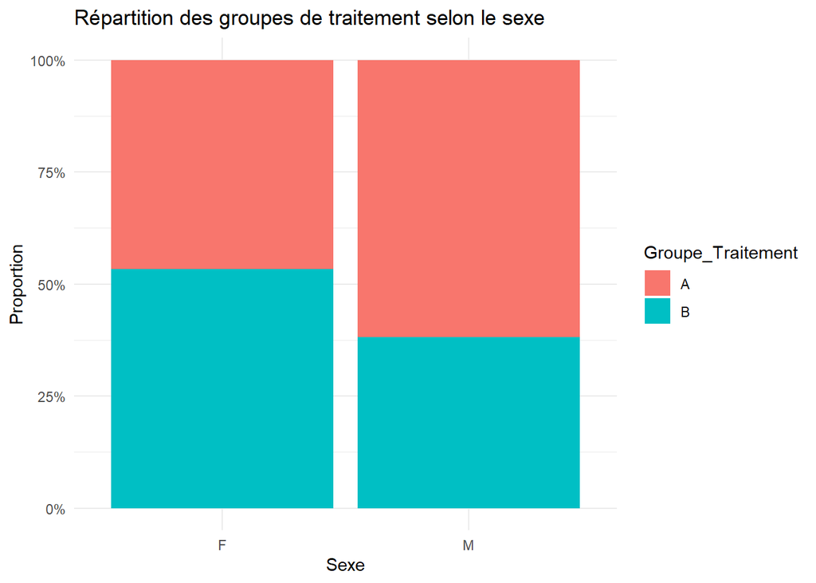

```r
ggplot(data, aes(x = Sexe, fill = Groupe_Traitement)) +
  geom_bar(position = "fill") +
  scale_y_continuous(labels = scales::percent) +
  labs(title = "Répartition des groupes de traitement selon le sexe",
       x = "Sexe",
       y = "Proportion") +
  theme_minimal()
```

# 5 Analyse multivariée

## 5.1 Régression linéaire multiple

```r
model_lm <- lm(
  Symptom_Score ~ Age + Poids + Tension + Cholesterol +
    Sexe + Groupe_Traitement + Suivi_Jours,
  data = data
)

summary(model_lm)
```

```
##
## Call:
## lm(formula = Symptom_Score ~ Age + Poids + Tension + Cholesterol +
##     Sexe + Groupe_Traitement + Suivi_Jours, data = data)
##
## Residuals:
##     Min      1Q  Median      3Q     Max
## -5.4514 -2.0247  0.2219  2.0510  4.5342
##
## Coefficients:
##                     Estimate Std. Error t value Pr(>|t|)
## (Intercept)         9.207592   4.656931   1.977   0.0523 .
## Age                 0.022730   0.019950   1.139   0.2588
## Poids               0.009679   0.022673   0.427   0.6709
## Tension            -0.017937   0.018220  -0.984   0.3286
## Cholesterol        -0.001958   0.011546  -0.170   0.8659
## SexeM              -0.319888   0.727147  -0.440   0.6615
## Groupe_TraitementB -0.352014   0.668319  -0.527   0.6002
## Suivi_Jours        -0.081172   0.095565  -0.849   0.3988
## ---
## Signif. codes:  0 '***' 0.001 '**' 0.01 '*' 0.05 '.' 0.1 ' ' 1
##
## Residual standard error: 2.691 on 64 degrees of freedom
## Multiple R-squared:  0.06689,    Adjusted R-squared:  -0.03517
## F-statistic: 0.6554 on 7 and 64 DF,  p-value: 0.7085
```

```r
broom::tidy(model_lm, conf.int = TRUE)
```

```
## # A tibble: 8 × 7
##   term               estimate std.error statistic p.value conf.low conf.high
##   <chr>                 <dbl>     <dbl>     <dbl>   <dbl>    <dbl>     <dbl>
## 1 (Intercept)         9.21       4.66       1.98   0.0523  -0.0957   18.5
## 2 Age                 0.0227     0.0200     1.14   0.259   -0.0171    0.0626
## 3 Poids               0.00968    0.0227     0.427  0.671   -0.0356    0.0550
## 4 Tension            -0.0179     0.0182    -0.984  0.329   -0.0543    0.0185
## 5 Cholesterol        -0.00196    0.0115    -0.170  0.866   -0.0250    0.0211
## 6 SexeM              -0.320      0.727     -0.440  0.661   -1.77      1.13
## 7 Groupe_TraitementB -0.352      0.668     -0.527  0.600   -1.69      0.983
## 8 Suivi_Jours        -0.0812     0.0956    -0.849  0.399   -0.272     0.110
```

## 5.2 Diagnostic du modèle

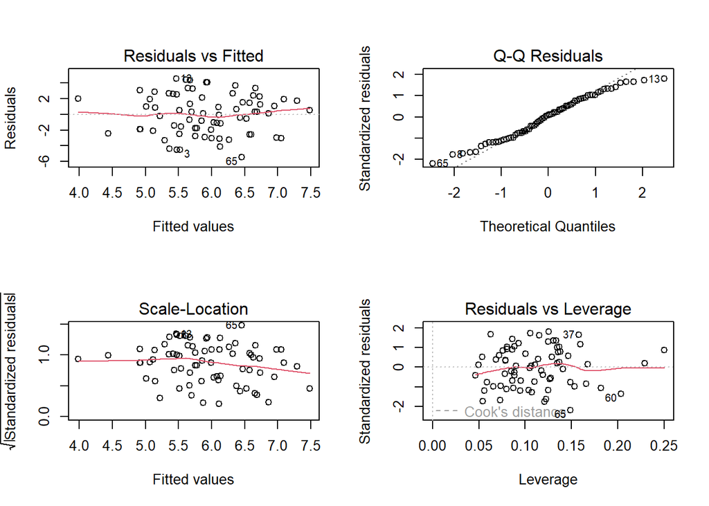

```r
par(mfrow = c(2, 2))
plot(model_lm)
```

```r
par(mfrow = c(1, 1))
```

# 6 Modélisation multivariée avancée

## 6.1 MANOVA globale

```r
model_mv <- lm(
cbind(Tension, Cholesterol, Symptom_Score) ~
Age + Poids + Sexe + Groupe_Traitement + Suivi_Jours,
data = data
)
summary(manova(model_mv), test = "Pillai")
```

```
##                   Df   Pillai approx F num Df den Df  Pr(>F)
## Age                1 0.033276  0.73433      3     64 0.53536
## Poids              1 0.024813  0.54282      3     64 0.65474
## Sexe               1 0.097678  2.30937      3     64 0.08472 .
## Groupe_Traitement  1 0.008001  0.17206      3     64 0.91490
## Suivi_Jours        1 0.012966  0.28024      3     64 0.83946
## Residuals         66
## ---
## Signif. codes:  0 '***' 0.001 '**' 0.01 '*' 0.05 '.' 0.1 ' ' 1
```

# 7 Régressions univariées (modèles séparés)

### 7.0.1 Modèle 1 : Tension artérielle

```r
model_Tension <- lm(
Tension ~ Age + Poids + Sexe + Groupe_Traitement + Suivi_Jours,
data = data
)
summary(model_Tension)
```

```
##
## Call:
## lm(formula = Tension ~ Age + Poids + Sexe + Groupe_Traitement +
##     Suivi_Jours, data = data)
##
## Residuals:
##     Min      1Q  Median      3Q     Max
## -33.204 -10.549  -0.419   9.442  51.755
##
## Coefficients:
##                     Estimate Std. Error t value Pr(>|t|)
## (Intercept)        158.72209   20.94031   7.580  1.5e-10 ***
## Age                 -0.08443    0.13484  -0.626   0.5334
## Poids               -0.19821    0.15100  -1.313   0.1938
## SexeM              -10.56119    4.69869  -2.248   0.0279 *
## Groupe_TraitementB   0.15124    4.52857   0.033   0.9735
## Suivi_Jours         -0.16174    0.64738  -0.250   0.8035
## ---
## Signif. codes:  0 '***' 0.001 '**' 0.01 '*' 0.05 '.' 0.1 ' ' 1
##
## Residual standard error: 18.25 on 66 degrees of freedom
## Multiple R-squared:  0.08525,    Adjusted R-squared:  0.01595
## F-statistic:  1.23 on 5 and 66 DF,  p-value: 0.305
```

### 7.0.2 Modèle 2 : Cholestérol

```r
model_Cholesterol <- lm(
Cholesterol ~ Age + Poids + Sexe + Groupe_Traitement + Suivi_Jours,
data = data
)
summary(model_Cholesterol)
```

```
##
## Call:
## lm(formula = Cholesterol ~ Age + Poids + Sexe + Groupe_Traitement +
##     Suivi_Jours, data = data)
##
## Residuals:
##     Min      1Q  Median      3Q     Max
## -75.063 -17.911   0.613  18.041  52.280
##
## Coefficients:
##                    Estimate Std. Error t value Pr(>|t|)
## (Intercept)        191.1352    33.0428   5.784 2.18e-07 ***
## Age                 -0.0518     0.2128  -0.243    0.808
## Poids                0.1709     0.2383   0.717    0.476
## SexeM                7.9834     7.4143   1.077    0.286
## Groupe_TraitementB  -2.0594     7.1459  -0.288    0.774
## Suivi_Jours          0.2260     1.0215   0.221    0.826
## ---
## Signif. codes:  0 '***' 0.001 '**' 0.01 '*' 0.05 '.' 0.1 ' ' 1
##
## Residual standard error: 28.79 on 66 degrees of freedom
## Multiple R-squared:  0.03062,    Adjusted R-squared:  -0.04282
## F-statistic: 0.417 on 5 and 66 DF,  p-value: 0.8353
```

### 7.0.3 Modèle 3 : Score de symptômes

```r
model_Symptom <- lm(
Symptom_Score ~ Age + Poids + Sexe + Groupe_Traitement + Suivi_Jours,
data = data
)
summary(model_Symptom)
```

```
##
## Call:
## lm(formula = Symptom_Score ~ Age + Poids + Sexe + Groupe_Traitement +
##     Suivi_Jours, data = data)
##
## Residuals:
##     Min      1Q  Median      3Q     Max
## -4.9843 -2.2483  0.0081  2.1589  5.0608
##
## Coefficients:
##                    Estimate Std. Error t value Pr(>|t|)
## (Intercept)         5.98639    3.06562   1.953   0.0551 .
## Age                 0.02435    0.01974   1.233   0.2218
## Poids               0.01290    0.02211   0.584   0.5615
## SexeM              -0.14609    0.68788  -0.212   0.8325
## Groupe_TraitementB -0.35069    0.66297  -0.529   0.5986
## Suivi_Jours        -0.07871    0.09478  -0.831   0.4092
## ---
## Signif. codes:  0 '***' 0.001 '**' 0.01 '*' 0.05 '.' 0.1 ' ' 1
##
## Residual standard error: 2.671 on 66 degrees of freedom
## Multiple R-squared:  0.05182,    Adjusted R-squared:  -0.02001
## F-statistic: 0.7214 on 5 and 66 DF,  p-value: 0.6097
```

### 7.0.4 Tableau global des coefficients

```r
bind_rows(
broom::tidy(model_Tension, conf.int = TRUE) %>% mutate(Outcome = "Tension"),
broom::tidy(model_Cholesterol, conf.int = TRUE) %>% mutate(Outcome = "Cholestérol"),
broom::tidy(model_Symptom, conf.int = TRUE) %>% mutate(Outcome = "Score symptômes")
) %>%
select(Outcome, term, estimate, conf.low, conf.high, p.value)
```

```
## # A tibble: 18 × 6
##    Outcome         term               estimate conf.low conf.high  p.value
##    <chr>           <chr>                 <dbl>    <dbl>     <dbl>    <dbl>
##  1 Tension         (Intercept)        159.     117.      201.     1.50e-10
##  2 Tension         Age                 -0.0844  -0.354     0.185  5.33e- 1
##  3 Tension         Poids               -0.198   -0.500     0.103  1.94e- 1
##  4 Tension         SexeM              -10.6    -19.9      -1.18   2.79e- 2
##  5 Tension         Groupe_TraitementB   0.151   -8.89      9.19   9.73e- 1
##  6 Tension         Suivi_Jours         -0.162   -1.45      1.13   8.03e- 1
##  7 Cholestérol     (Intercept)        191.     125.      257.     2.18e- 7
##  8 Cholestérol     Age                 -0.0518  -0.477     0.373  8.08e- 1
##  9 Cholestérol     Poids                0.171   -0.305     0.647  4.76e- 1
## 10 Cholestérol     SexeM                7.98    -6.82     22.8    2.86e- 1
## 11 Cholestérol     Groupe_TraitementB  -2.06   -16.3      12.2    7.74e- 1
## 12 Cholestérol     Suivi_Jours          0.226   -1.81      2.27   8.26e- 1
## 13 Score symptômes (Intercept)          5.99    -0.134    12.1    5.51e- 2
## 14 Score symptômes Age                  0.0243  -0.0151    0.0638 2.22e- 1
## 15 Score symptômes Poids                0.0129  -0.0312    0.0570 5.62e- 1
## 16 Score symptômes SexeM               -0.146   -1.52      1.23   8.32e- 1
## 17 Score symptômes Groupe_TraitementB  -0.351   -1.67      0.973  5.99e- 1
## 18 Score symptômes Suivi_Jours         -0.0787  -0.268     0.111  4.09e- 1
```

# 8 Diagnostics des modèles

## 8.1 Diagnostics graphiques classiques

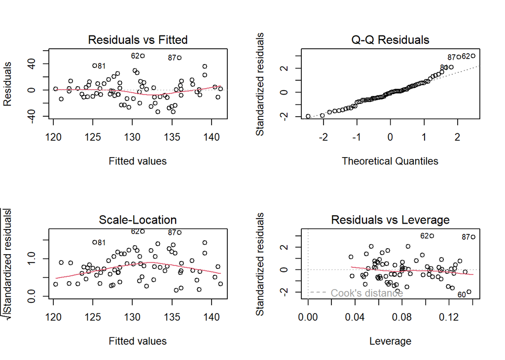

```r
par(mfrow = c(2,2))
plot(model_Tension)
```

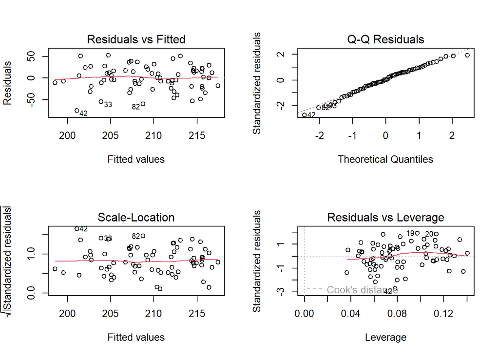

```r
plot(model_Cholesterol)
```

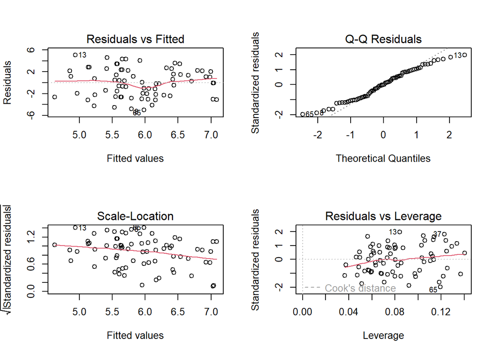

```r
plot(model_Symptom)
```

```r
par(mfrow = c(1,1))
```

## 8.2 Multicolinéarité (VIF)

```r
# Installer le package 'car' une seule fois
# install.packages("car")

# Charger le package
library(car)

# Calcul des VIF
vif(model_Tension)
```

```
##               Age             Poids              Sexe Groupe_Traitement
##          1.097564          1.094169          1.160548          1.095144
##       Suivi_Jours
##          1.034813
```

```r
vif(model_Cholesterol)
```

```
##               Age             Poids              Sexe Groupe_Traitement
##          1.097564          1.094169          1.160548          1.095144
##       Suivi_Jours
##          1.034813
```

```r
vif(model_Symptom)
```

```
##               Age             Poids              Sexe Groupe_Traitement
##          1.097564          1.094169          1.160548          1.095144
##       Suivi_Jours
##          1.034813
```

## 8.3 Interprétation des VIF (Variance Inflation Factor) :

Les VIF calculés pour les variables explicatives de nos modèles (Age, Poids, Sexe, Groupe_Traitement, Suivi_Jours) sont tous compris entre 1 et 1,16.

Ces valeurs sont très proches de 1, ce qui indique que les variables ne sont pas corrélées entre elles.

Aucun problème de multicolinéarité n’est détecté.

Cela signifie que les coefficients estimés dans les modèles de régression peuvent être interprétés de manière fiable, sans distorsion due à des corrélations fortes entre variables explicatives. Conclusion : Les facteurs inclus dans les modèles sont indépendants les uns des autres pour l’analyse, et les résultats des régressions sont fiables.